# *qcCHIP* User’s Guide

# Basic Usage of *qcCHIP*

In this section, we use *qcCHIP* to test the results of select CHIP candidate with different setting of VAF, DP, or population. The resulting figures and comparision summary file will help user diceide the optimal VAF, DP, or population metric for their dataset.

### *Run qcCHIP with change of minimum VAF*

This section demonstrates the usage of *qcCHIP* when use different setting of minimum VAF.

```r
# input file
input_path<- system.file("extdata","demo_input.txt",package="qcCHIP")
in_f <- read.table(input_path,sep="\t",header=T)

# create test directory
out_dir <- paste0(getwd(),"/vaf_test")
vaf_permut <- qcCHIP(in_f,out_path = out_dir
                     ,metric_min = 0,
                     metric_step = 0.02,
                     metric_max = 0.1,
                     core=1,
                     show_info = F)

# example of comparision summary output
head(vaf_permut$summary_df)
```

|  | metric_name | metric_setting | group_size | permut_index | var_n_whole | var_n_sub | union_n | common_n | whole_only | sub_only | common_whole | common_sub |
| --- | --- | --- | --- | --- | --- | --- | --- | --- | --- | --- | --- | --- |
| 1 | VAF | 0 | 2 | 1 | 221 | 221 | 221 | 221 | 0 | 0 | 1.000 | 1 |
| 2 | VAF | 0 | 2 | 2 | 221 | 221 | 221 | 221 | 0 | 0 | 1.000 | 1 |
| 3 | VAF | 0 | 2 | 3 | 221 | 221 | 221 | 221 | 0 | 0 | 1.000 | 1 |
| 4 | VAF | 0 | 2 | 4 | 221 | 221 | 221 | 221 | 0 | 0 | 1.000 | 1 |
| 5 | VAF | 0 | 2 | 5 | 221 | 221 | 221 | 221 | 0 | 0 | 1.000 | 1 |
| 6 | VAF | 0 | 2 | 6 | 221 | 205 | 221 | 205 | 16 | 0 | 0.928 | 1 |

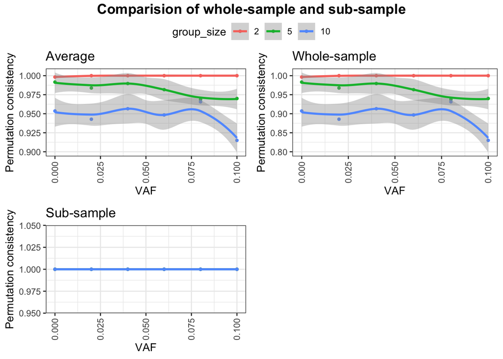

```r
# permutation consistency plot
vaf_permut$figs
```

### *Run qcCHIP with change of minimum DP*

This section demonstrates the usage of *qcCHIP* when use different setting of minimum DP.

```r
# input file
input_path<- system.file("extdata","demo_input.txt",package="qcCHIP")
in_f <- read.table(input_path,sep="\t",header=T)

# create test directory
out_dir <- paste0(getwd(),"/DP_test")
DP_permut <- qcCHIP(in_f,out_path = out_dir,permut_metrics = "DP",
                    metric_min = 0,
                    metric_step = 10,
                    metric_max = 50,
                    core=1,
                    show_info = F)

# example of comparision summary output
head(DP_permut$summary_df)
```

|  | metric_name | metric_setting | group_size | permut_index | var_n_whole | var_n_sub | union_n | common_n | whole_only | sub_only | common_whole | common_sub |
| --- | --- | --- | --- | --- | --- | --- | --- | --- | --- | --- | --- | --- |
| 1 | DP | 0 | 2 | 1 | 148 | 148 | 148 | 148 | 0 | 0 | 1 | 1 |
| 2 | DP | 0 | 2 | 2 | 148 | 148 | 148 | 148 | 0 | 0 | 1 | 1 |
| 3 | DP | 0 | 2 | 3 | 148 | 148 | 148 | 148 | 0 | 0 | 1 | 1 |
| 4 | DP | 0 | 2 | 4 | 148 | 148 | 148 | 148 | 0 | 0 | 1 | 1 |
| 5 | DP | 0 | 2 | 5 | 148 | 148 | 148 | 148 | 0 | 0 | 1 | 1 |
| 6 | DP | 0 | 2 | 6 | 148 | 148 | 148 | 148 | 0 | 0 | 1 | 1 |

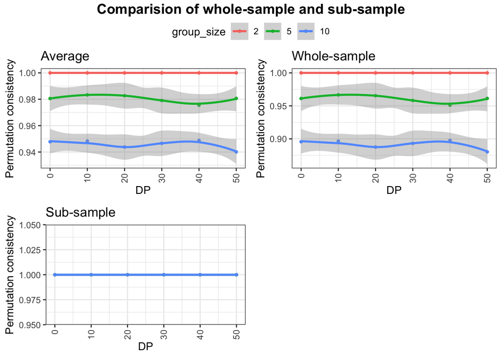

```r
# permutation consistency plot
DP_permut$figs
```

### *Run qcCHIP with change of maximum population percentage*

This section demonstrates the usage of *qcCHIP* when use different setting of maximum population percentage.

```r
# input file
input_path<- system.file("extdata","demo_input.txt",package="qcCHIP")
in_f <- read.table(input_path,sep="\t",header=T)

# create test directory
out_dir <- paste0(getwd(),"/population_test")
pop_permut <- qcCHIP(in_f,out_path = out_dir,permut_metrics = "population",
                    metric_min = 0.05,
                    metric_step = 0.05,
                    metric_max = 0.5,
                    core=1,
                    show_info = F)

# example of comparision summary output
head(pop_permut$summary_df)
```

|  | metric_name | metric_setting | group_size | permut_index | var_n_whole | var_n_sub | union_n | common_n | whole_only | sub_only | common_whole | common_sub |
| --- | --- | --- | --- | --- | --- | --- | --- | --- | --- | --- | --- | --- |
| 1 | population | 0.05 | 2 | 1 | 103 | 80 | 109 | 74 | 29 | 6 | 0.718 | 0.925 |
| 2 | population | 0.05 | 2 | 2 | 103 | 70 | 106 | 67 | 36 | 3 | 0.650 | 0.957 |
| 3 | population | 0.05 | 2 | 3 | 103 | 81 | 106 | 78 | 25 | 3 | 0.757 | 0.963 |
| 4 | population | 0.05 | 2 | 4 | 103 | 71 | 107 | 67 | 36 | 4 | 0.650 | 0.944 |
| 5 | population | 0.05 | 2 | 5 | 103 | 95 | 111 | 87 | 16 | 8 | 0.845 | 0.916 |
| 6 | population | 0.05 | 2 | 6 | 103 | 100 | 116 | 87 | 16 | 13 | 0.845 | 0.870 |

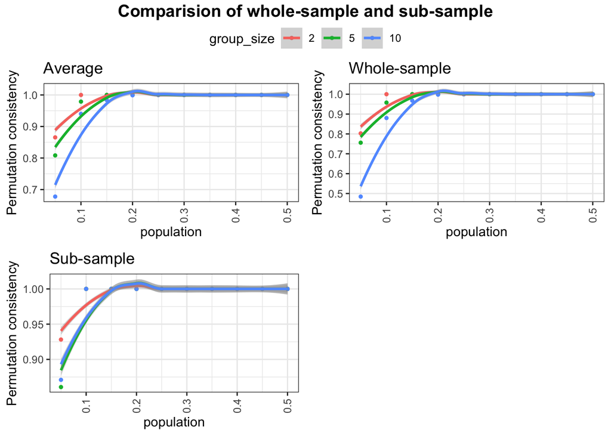

```r
# permutation consistency plot
pop_permut$figs
```

# Basic Usage of *CHIPfilter*

In this section, we use *CHIPfilter* to get the result of select CHIP candidate based on variety of selection matrics (detailed in the man page of *CHIPfilter*). The output will be a subset of input file which pass the selection. Users can directly use this function without runing *qcCHIP*. Some features of *CHIPfilter* are described below.

```r
# input file
input_path<- system.file("extdata","demo_input.txt",package="qcCHIP")
in_f <- read.table(input_path,sep="\t",header=T)

# blacklist region to exclude
bf_path<- system.file("extdata","demo_blacklist.bed",package="qcCHIP")

bl_f <- read.table(bf_path,sep = "\t",header=F)

# run default setting
out_1 <- CHIPfilter(in_f)
```

```
#> [1] "Perform population metrics"
#> [1] "Perform technique metrics"
#> [1] "No paired tumor sample, skip"
#> [1] "Perform functional metrics"
#> [1] "Perform not nonsunonymous metrics"
#> [1] "Perform gnomad metrics only"
#> [1] "No blacklist region bed file find, skip"
```

```r
# change different metrics
out_2 <- CHIPfilter(in_f,max_percent=0.02,DP_min = 40,VAF_min=0.002,info=F)

# with paired tumor sample
out_3 <- CHIPfilter(in_f,tumor_sample = T,tumor_VAF_min = 0.02,info=F)

# with gnomad or dpGAP reference file
out_4 <- CHIPfilter(in_f,gnomad = F,dpGAP = F,info=F)

# with blacklist region
out_5 <- CHIPfilter(in_f,blacklist_f = bl_f,info=F)

# check the number of CHIP
length(unique(out_1$mut_sample))
```

```
#> [1] 148
```

```r
length(unique(out_2$mut_sample))
```

```
#> [1] 71
```

```r
length(unique(out_3$mut_sample))
```

```
#> [1] 103
```

```r
length(unique(out_4$mut_sample))
```

```
#> [1] 148
```

```r
length(unique(out_5$mut_sample))
```

```
#> [1] 145
```